# DATA621 Final Project

Ivan Tikhonov, Seung Min Song, Alice Frieddman

## Abstract

This study investigates the external factors affecting students’ academic performance in secondary schools’ math and Portuguese language courses. Using a quantitative data set obtained through a survey, the study analyzes various external variables, such as students’ health, social and demographic factors, study habits, and other relevant factors to understand their impact on academic performance.

This study’s methodology and results will be of interest to researchers in the field of education, providing a basis for future studies on external factors that impact academic performance. Overall, the study’s findings have significant implications for the education sector, providing insights that can inform future efforts to support student academic success and improve educational outcomes. The study’s methodology and results are of interest to educators, policymakers, and other stakeholders in the education sector and can contribute to the development of evidence-based practices.

## Introduction

This study may be relevant to you as it explores the external factors that have an impact on students’ grades. By analyzing the various external variables that can influence academic performance, this study provides valuable insights that can help parents, educators, and policymakers to better support students’ success in school. Specifically, this study looks at factors such as students’ health, social and demographic factors, study habits, and other relevant factors that can have an impact on their academic performance.

Understanding the external factors that can affect a student’s academic performance can be helpful in creating a supportive home environment and developing effective strategies to help a child succeed in school. This study’s findings could also be useful for parents and educators to monitor and provide proper guidelines for external factors that may affect students’ academic performance, such as romantic relationships, drinking habits, and how they use their free time. By gaining a deeper understanding of how these factors impact students’ grades, parents and educators can work to create a more supportive environment for students and help them develop healthy habits that promote academic success.

In the wider educational industry, the findings of this study can provide insights into how to better support students’ academic success and enhance their overall educational experience. Educators and policymakers can use this research to identify areas where they can improve educational outcomes, such as implementing programs to support students’ health or providing resources to help students develop effective study habits.

## Key Words

- external factors
- internal factors
- academic performance
- Weighted Least Square Regression
- multiple linear regression
- health
- internet access
- study habits
- educational outcomes

## Literature Review

Academic success is a widely studied phenomenon. Previous studies have used Pearson’s partial correlations, moderated linear regression, or analysis of variance between groups (ANOVA) to determine the relationship between factors such as demographics (e.g. sex), lifestyle habits (e.g. screen time), and physical and cognitive abilities (e.g. cardiovascular fitness measured by VO2 Max) to predict academic achievement. All of the studies presented below attempt to understand factors associated with a *student* rather than a school or teacher that my predict academic success, and so (as is the case with our data set) look at cross-section of students at a single school, so that the school itself is not considered a factor. This is different from our data set which includes two high schools.

A large number of factors have been identified in previous studies to predict academic achievement including sex, screen time, sleep, cell-phone use, maternal education, IQ; however, the effect typically found is low (explaining between approximately 6% and 50% of variation). This indicates that other factors not included in the study (which may include student-specific habits like study habits or school-related factors like school quality) may impact variation, and that the true model is likely complex.

### [Title: Application of Multiple Linear Regression Identifying Contributing Factors in Students’Academic Achievement]((https://www.researchgate.net/publication/366929441_Application_of_Multiple_Linear_Regression_in_Identifying_Contributing_Factors_in_Students%27_Academic_Achievement)

Authors: Dg Siti Nurisya Sahirah Binti Ag Isha and Siti Rahayu Binti Mohd Hashim Proceedings of the International Conference on Mathematical Sciences and Statistics 2022 (ICMSS 2022)At: Selangor, Malaysia Mathematics With Economics Programme, Faculty of Science and Natural Resources, December 2022

This study aimed to identify significant factors that contribute to students’ academic success by analyzing internal and external factors. The study involved 327 final-year undergraduate students and found that self-esteem, intelligence, and maternal education were significant factors affecting students’ achievement.

In this research, they made three different models to see which factors were most important for academic achievement. They found that self-esteem, IQ, and maternal education were the most important factors.

### [Title: A Study on Academic Achievement and Personality of Secondary School Students](https://files.eric.ed.gov/fulltext/EJ1149330.pdf)

Authors: Dr. Suvarna V. D.and Dr H. S. Ganesha Bhata1 Research in Pedagogy, v6 n1 p99-108, 2016

This study uses ANOVA and the Pearson’s product-moment coefficient to test hypotheses related to differences in academic achievement between different groups of students (including both demographics and responses to a personality test ) using a data set of approximately 300 secondary school students.The results find that the students’ age and gender affect their achievement levels, but that other demographic categories and (interestingly) personality characteristics do not.

### [Predictors of Academic Performance in High School Students: The Longitudinal ASAP Study](https://www.ncbi.nlm.nih.gov/pmc/articles/PMC9365103/#:~:text=Finally%2C%20psychological%20factors%20such%20as,42%2C%2043%2C%2048).)

Authors: Marie-Maude Dubuc, Mylene Aubertin-Leheudr, and Antony D. Karelis Published online 2022 May 1, International Journal of Exercise

This study used moderated multivariate linear regression, separately comparing male and female students, to evaluate the impact of social, physical, and cognitive factors to explain variation in academic achievement among a cohort of 185 high-school students evaluated at a single high school over three years. The researchers controlled for demographic factors such as race, income, and ethnicity and use both a cross-sectional and longitudinal approach. In their results, they found that sex, cardiovascular fitness (measured by VO2 Max), and working memory were important predictors; however, they found that results differed when controlling for sex, school subject, and study design indicating that academic performance is in fact a highly complex phenomenon.

## Data Source

The data source is from a [Kaggle competition](https://www.kaggle.com/datasets/uciml/student-alcohol-consumption) and represents observations from 662 students at two high schools. The data is initially split into two data sets based on which subject is being observed (Portuguese language or math).

We will use the data set to predict academic achievement represented by the final grades, `G3`. A data dictionary is included in Appendix 1.

## Data Exploration

### Data Preparation

The first task is to merge the data sets, identifying which students are identical and which grades correspond to which class. We can consider the data in three ways: 1. Predicting achievement in math, with df_mat 2. Predicting achievement in language, with df_por 3. Predicting achievement in school independent of subject, with df_both, using a target `final_grade`, which is the average of both classes. Because students have answered with different number of absences in the different classes, we have also averahed the absences in this dataset. There are 370 records with identical features in both datasets outside of the grades and absences, which are presumed to be specific to the subject. The field `paid` refers to subject-specific paid tutoring.

[output not shown]

### Overall Statistics

To gain comprehensive insights, we can merge *df_mat* and *df_por* data sets and analyze their collective statistics by looking at studends in both classes.

`A full descriptive summary of variables in included in Appendix 2.

### Basic Plots

Basic plots of numeric variables help us understand if they have a normal distribution – necessary to undestand if a particular model type will be appropriate. In general, we can see most features are not normally distributed, meaning that linear regression is not likely to have good predictive value. Basic plots are included in Appendix 3.

### Correlation

When considering the distribution of *traveltime*, *studytime*, *failures*, *famrel*, *freetime*, *goout*, *Dalc*, *Walc*, *health*, and *absences* across different categories, it becomes evident that these variables show a relatively even distribution within each G3 group. Grades and absences between the classse are highly correlated, so it makes sense to combine these for futher analysis.

We establish the presences or absence of multicollinearity in order to again determine the suitability of different model approaches, or determine if we should consider dropping some variables.

We can see that mother’s and father’s education (`Medu` and `Fadu`) as well as daily and weekly alcholol consumption (`Dalc` and `Walc`) are highly correlate.

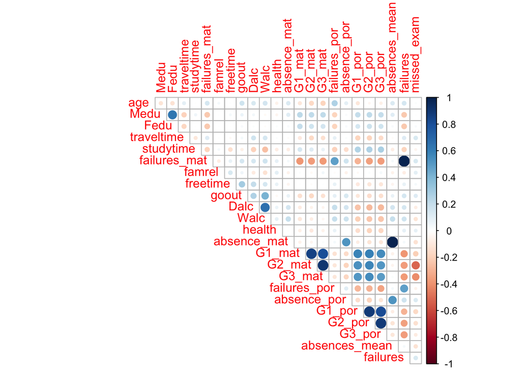

### Missing values

The data set is complete with no missing values; however in merging the two datasets we had to make a decision for how to deal with variables that are subject specific. this treatment is described below.

### Adding new columns

We used the dplyr::mutate() method to create a new columns in the `df_both` data set: `final_grade`: an average of the final grade for both classes `absences_mean`: average absences reported across both classes `parentEdu`: sum of `Medu` + `Fedu` to remove a collinearity and combine parental education into a single variable `paid_tutor`: this column is marked as “yes” if the student receives paid tutoring in either subject `missed_exam`: this column indicates whether a student missed an exam in any class

### Replacing binary values

For easier computation and interpretation of results, we replace all binary data (“yes”, “no”; “rural” or “urban”; “m” or “f”) with 1 or 0.

## Data Visualization

We can use box plots to understand the impact of factor variables on the target final grade. We can see that `failures` jumps out as having significant predictive value, whle the presence of absence of a paid tutor makes little difference

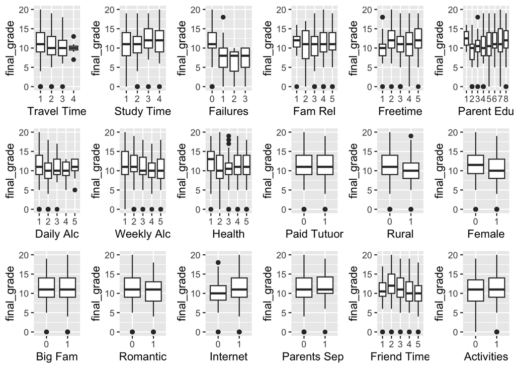

In order to determine how best to measure overall student achievement across the classes, we evaluate the correlation between `G3_mat` and `G3_por`. In general, it appears that these correlation between these two subjects is quite high, especially if we omit final grades of “0” from consideration; this is helpful because it gives us a sense of the upper bound of how much variation in achievement can be explained by other features – this correlation, after all, is for final grades for different classes but for the same students.

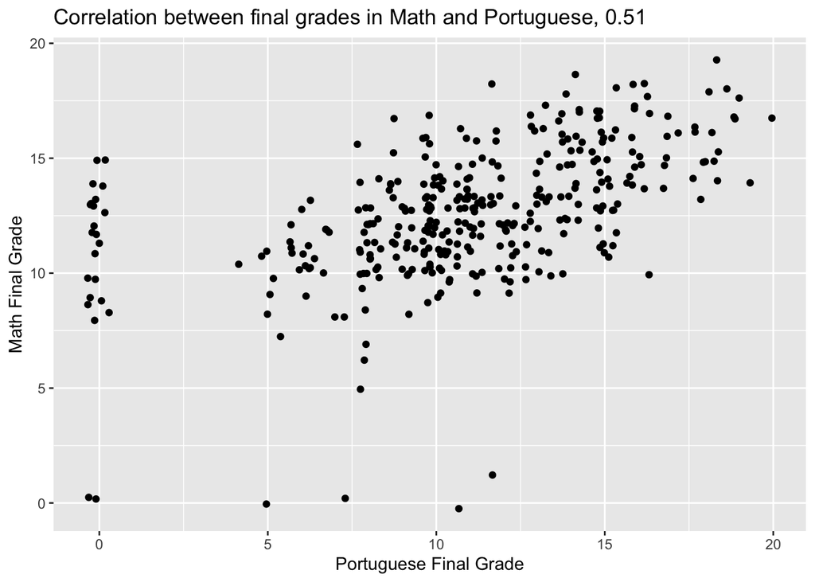

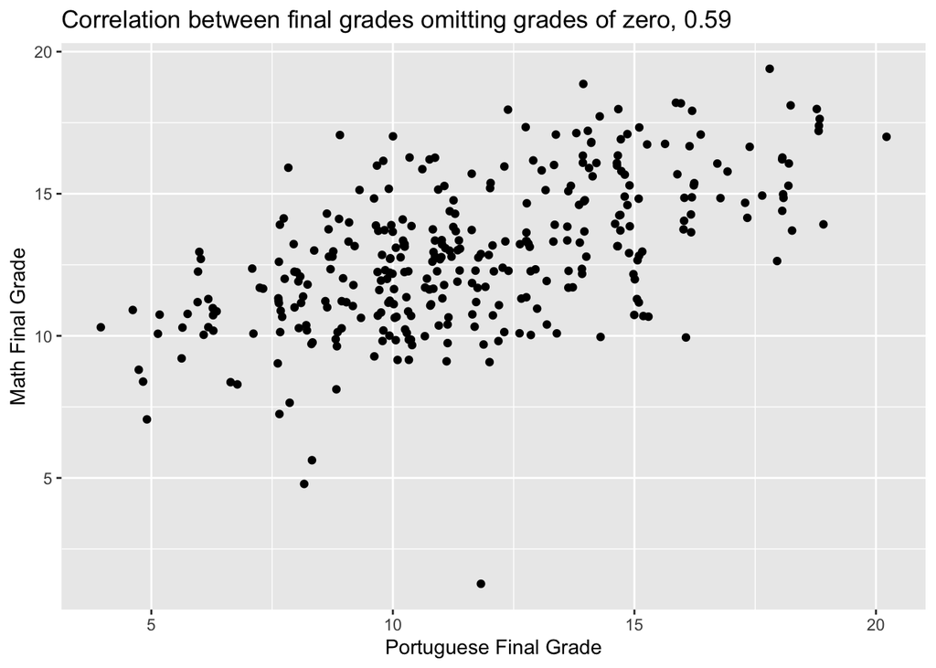

### Romantic status

In general, students who are in a romantic relationship may have a more challenging time focusing on their studies compared to those who are not. A plot indicates that this may be the case – especially male students who are not romantically involved appear to have a slightly higher final grade; ANOVA confirms that romantic status and sex both have significant predictive value.

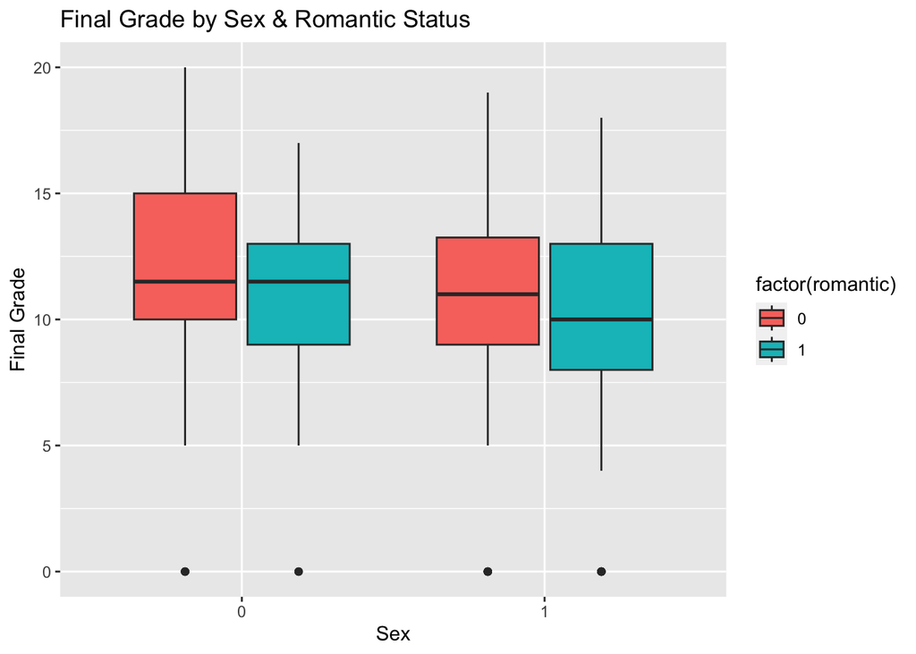

```
##              Df Sum Sq Mean Sq F value Pr(>F)
## romantic      1     74   73.61   4.152 0.0423 *
## sex_F         1    107  106.65   6.015 0.0147 *
## Residuals   354   6276   17.73
## ---
## Signif. codes:  0 '***' 0.001 '**' 0.01 '*' 0.05 '.' 0.1 ' ' 1
```

### Study Time

Although at first glance the findings suggest that students who study for a longer duration have a higher average score compared to those who study for a shorter duration, study time is not predictive according to ANOVA and we cannot rule out chance.

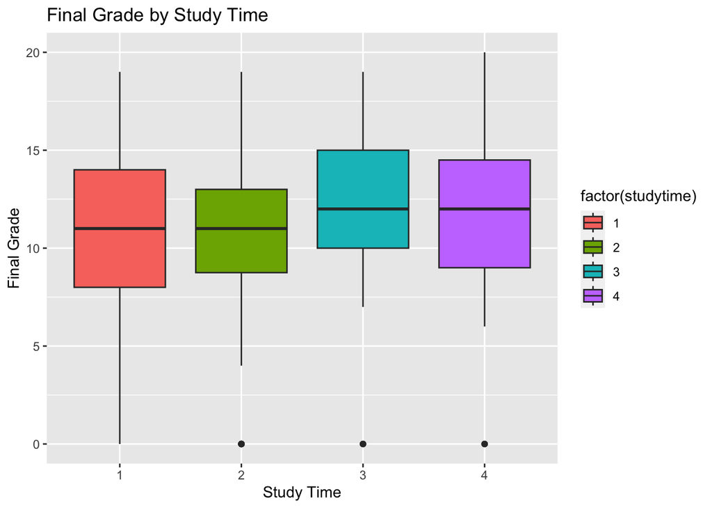

```
##              Df Sum Sq Mean Sq F value Pr(>F)
## studytime     1     26   26.20   1.447   0.23
## Residuals   355   6430   18.11
```

### Internet

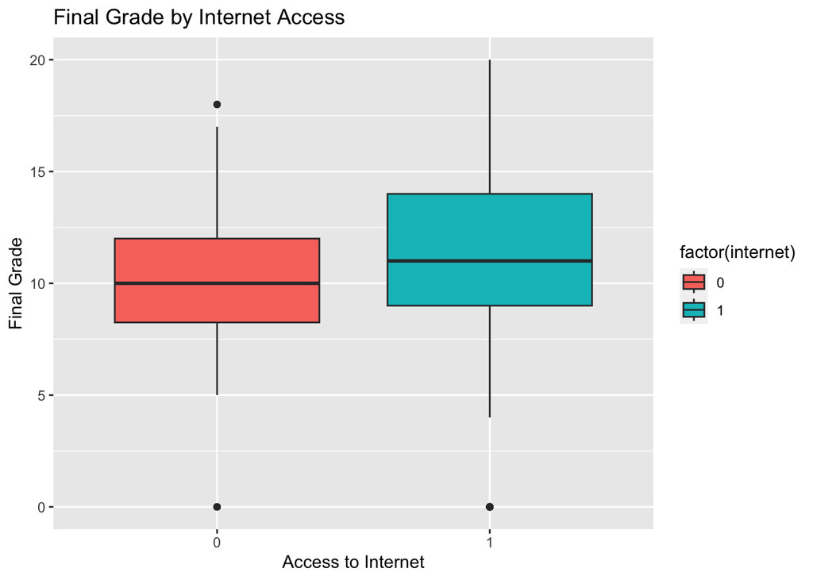

```
##              Df Sum Sq Mean Sq F value Pr(>F)
## internet      1     44   43.74   2.421  0.121
## Residuals   355   6413   18.06
```

## Models

We will attempt to predict the target, `final_grade` using three approaches: multiple linear regression, random forrest, and a decision tree.

### Model 1

**Multiple Linear Regrssion** We will first attempt the simplest case multiple linear regression using the full subset method to choose the best linear model. Using the `leaps` package and 3-fold cross validation from the `caret` package, we can select the best performing model among possile linear regression strategies.

What is very interesting about this result is that the same best subset is not created for each fold – this indicates that the relationships are not especially strong, except for those few that appear each time. The only consistent result with this methodology is to include `failures`: Students who have previously failed a class are more likely to fail again.

A visualization and ANOVA confirm this results – students who have previously failed are significantly likely to have a lower final grade than students who have never failed.

The coefficients in the best subset with 3 features are `failure`, `sex_f` and `parentEDU` – not dissimilar from results from previous studies.

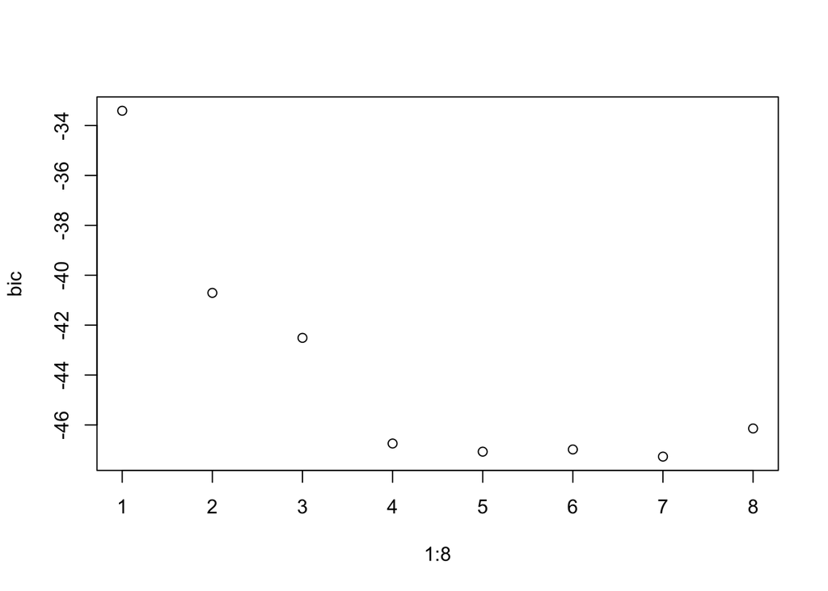

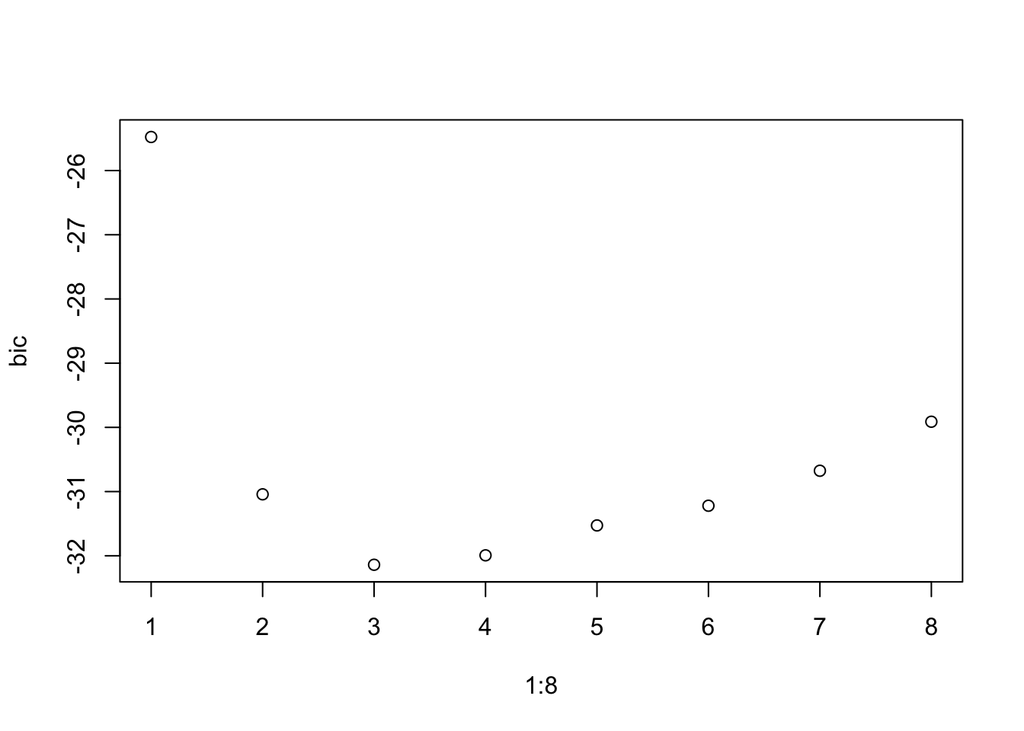

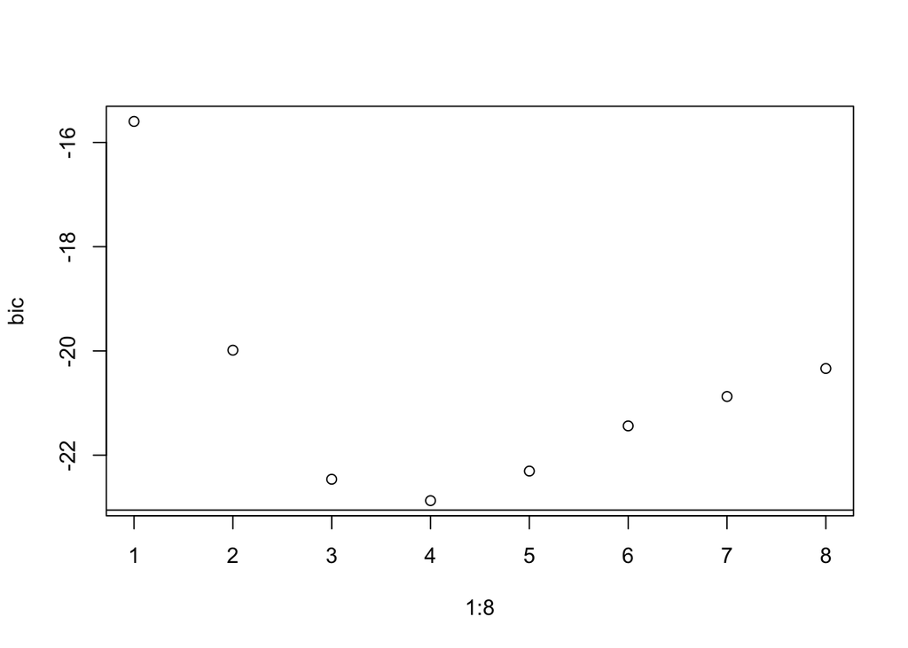

```
## [1] 0.3959489
```

```
## [1] 0.180418
```

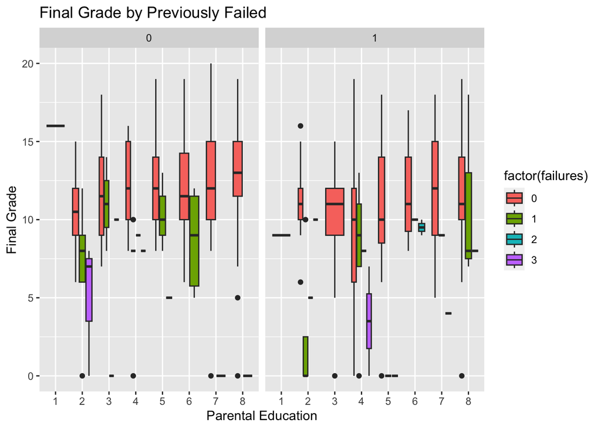

```
##              Df Sum Sq Mean Sq F value   Pr(>F)
## failures      1    877   876.9  58.033 2.39e-13 ***
## sex_F         1    138   137.5   9.103  0.00274 **
## parentEdu     1    108   108.5   7.178  0.00773 **
## Residuals   353   5334    15.1
## ---
## Signif. codes:  0 '***' 0.001 '**' 0.01 '*' 0.05 '.' 0.1 ' ' 1
```

```
## Start:  AIC=652.48
## final_grade ~ sex_F + failures + parentEdu
##
##                      Df Sum of Sq    RSS    AIC
## + failures:parentEdu  1     37.75 3557.6 651.98
## - sex_F               1     23.34 3618.6 652.01
## <none>                            3595.3 652.48
## + sex_F:parentEdu     1     28.36 3566.9 652.60
## + sex_F:failures      1     26.28 3569.0 652.74
## - parentEdu           1     54.23 3649.5 654.03
## - failures            1    625.64 4221.0 688.50
##
## Step:  AIC=651.98
## final_grade ~ sex_F + failures + parentEdu + failures:parentEdu
##
##                      Df Sum of Sq    RSS    AIC
## - sex_F               1    22.973 3580.5 651.50
## + sex_F:parentEdu     1    32.737 3524.8 651.79
## <none>                            3557.6 651.98
## - failures:parentEdu  1    37.752 3595.3 652.48
## + sex_F:failures      1    19.039 3538.5 652.71
##
## Step:  AIC=651.5
## final_grade ~ failures + parentEdu + failures:parentEdu
##
##                      Df Sum of Sq    RSS    AIC
## <none>                            3580.5 651.50
## + sex_F               1    22.973 3557.6 651.98
## - failures:parentEdu  1    38.116 3618.6 652.01
```

```
##
## Call:
## lm(formula = final_grade ~ failures + parentEdu + failures:parentEdu,
##     data = train_data)
##
## Residuals:
##      Min       1Q   Median       3Q      Max
## -12.4048  -1.9934  -0.0519   2.7123   9.6478
##
## Coefficients:
##                    Estimate Std. Error t value Pr(>|t|)
## (Intercept)          9.5820     0.8160  11.743   <2e-16 ***
## failures            -1.3601     0.9579  -1.420   0.1570
## parentEdu            0.3529     0.1421   2.483   0.0137 *
## failures:parentEdu  -0.3366     0.2137  -1.575   0.1166
## ---
## Signif. codes:  0 '***' 0.001 '**' 0.01 '*' 0.05 '.' 0.1 ' ' 1
##
## Residual standard error: 3.92 on 233 degrees of freedom
## Multiple R-squared:  0.1941, Adjusted R-squared:  0.1837
## F-statistic: 18.71 on 3 and 233 DF,  p-value: 6.615e-11
```

```
## [1] 0.3596584
```

```
## [1] 3.918136
```

```
## [1] 3.904344
```

### Model 2

**Random Forest Model**

```
##
## Call:
##  randomForest(formula = final_grade ~ traveltime + studytime +      failures + schoolsup + famEdsup + paid_tutor + activities +      nursery + higher + internet + romantic + famrel + freetime +      friendtime + dayAlc + weekAlc + health + absences_mean +      parentEdu, data = train_data)
##                Type of random forest: regression
##                      Number of trees: 500
## No. of variables tried at each split: 6
##
##           Mean of squared residuals: 14.97917
##                     % Var explained: 20.1
```

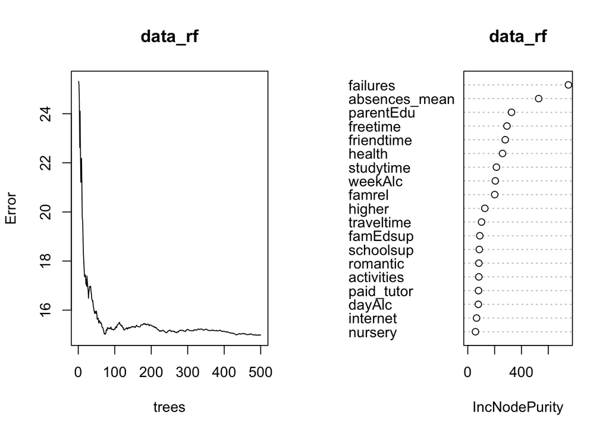

```
## [1] 3.680065
```

```
## [1] 0.4438688
```

### Model 3

**Decision tree model**

```
## n= 237
##
## node), split, n, deviance, yval
##       * denotes terminal node
##
##   1) root 237 4442.86900 10.793250
##     2) failures>=0.5 38  809.36840  6.263158
##       4) absences_mean< 1 14  268.35710  2.214286 *
##       5) absences_mean>=1 24  177.62500  8.625000 *
##     3) failures< 0.5 199 2704.76400 11.658290
##       6) health>=2.5 148 2016.18900 11.229730
##        12) friendtime>=3.5 40  528.77500 10.075000
##          24) weekAlc< 1.5 10  154.10000  7.300000 *
##          25) weekAlc>=1.5 30  272.00000 11.000000 *
##        13) friendtime< 3.5 108 1414.32400 11.657410
##          26) famEdsup>=0.5 69 1013.47800 11.086960
##            52) schoolsup>=0.5 10  126.10000  8.700000 *
##            53) schoolsup< 0.5 59  820.74580 11.491530
##             106) absences_mean>=11.5 7   85.71429  8.428571 *
##             107) absences_mean< 11.5 52  660.51920 11.903850
##               214) studytime< 1.5 9  130.00000  9.666667 *
##               215) studytime>=1.5 43  476.04650 12.372090
##                 430) health< 3.5 18  280.94440 10.944440 *
##                 431) health>=3.5 25  132.00000 13.400000 *
##          27) famEdsup< 0.5 39  338.66670 12.666670 *
##       7) health< 2.5 51  582.50980 12.901960
##        14) freetime>=2.5 39  415.43590 12.256410
##          28) absences_mean>=9.5 7   37.71429  9.428571 *
##          29) absences_mean< 9.5 32  309.50000 12.875000 *
##        15) freetime< 2.5 12   98.00000 15.000000 *
```

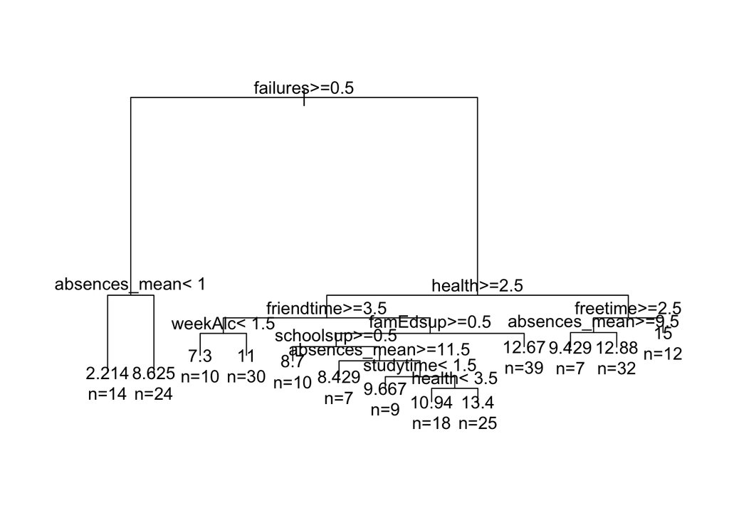

```
## [1] 4.204514
```

```
## [1] 0.2913465
```

## Model Selection

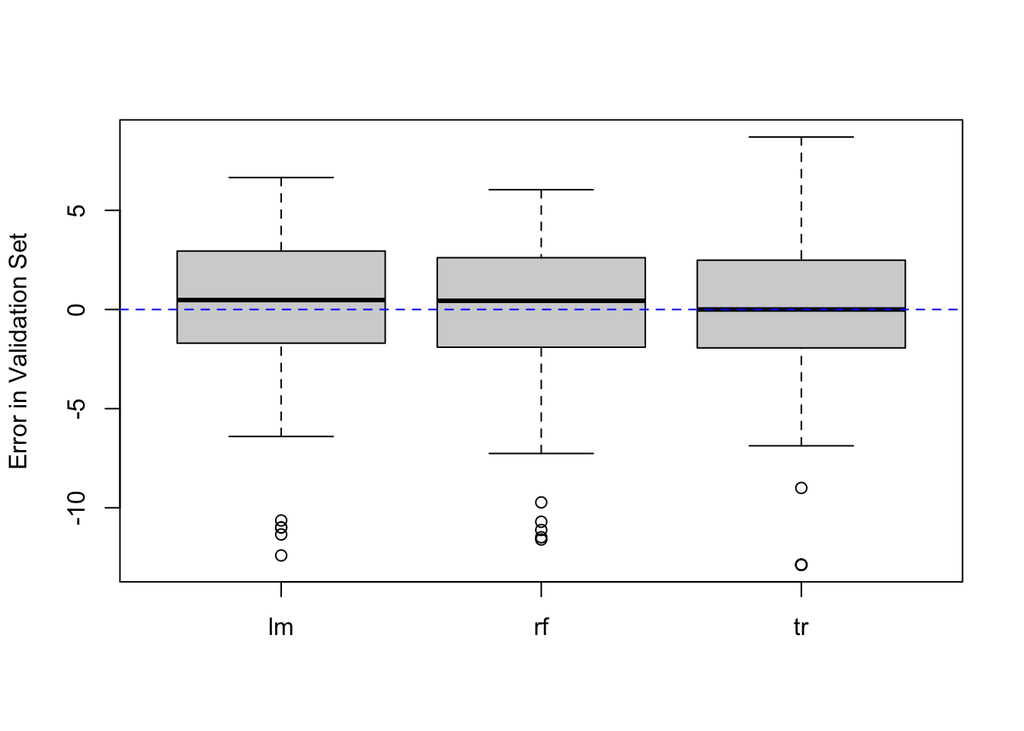

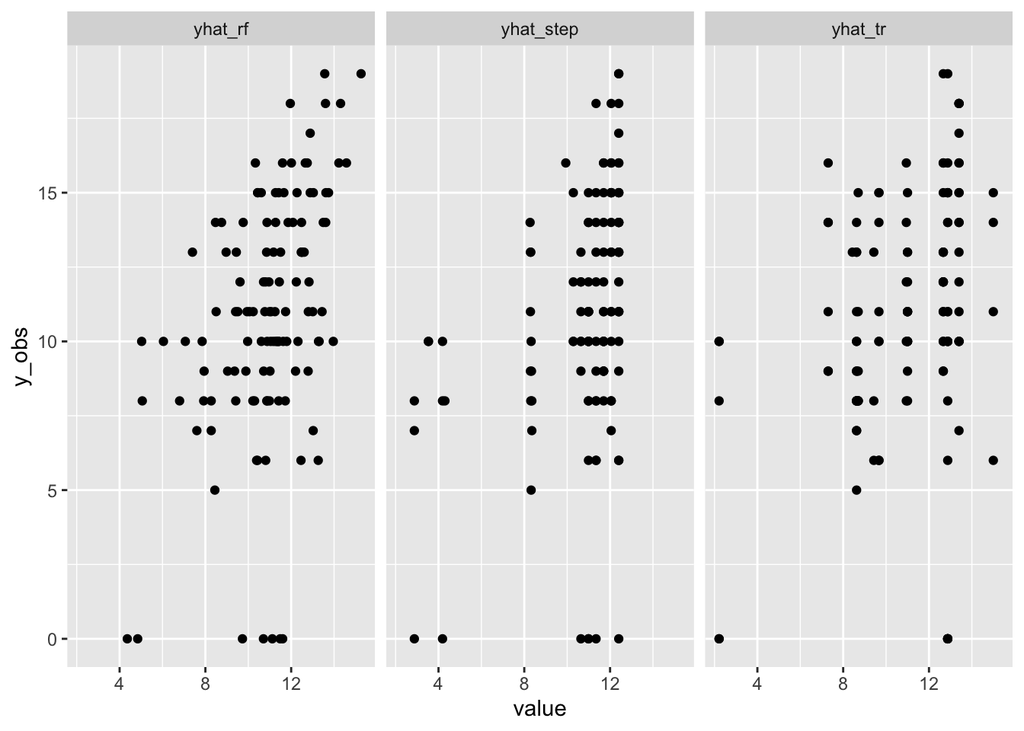

## References

Data source: P. Cortez and A. Silva. Using Data Mining to Predict Secondary School Student Performance. In A. Brito and J. Teixeira Eds., Proceedings of 5th Future Business Technology Conference (FUBUTEC 2008) pp. 5-12, Porto, Portugal, April, 2008, EUROSIS, ISBN 978-9077381-39-7. Accessed via [Kaggle](https://www.kaggle.com/datasets/uciml/student-alcohol-consumption)

## Appendix 1: Data Dictionary

(from [Kaggle](https://www.kaggle.com/datasets/uciml/student-alcohol-consumption))

- *absences* - number of school absences (numeric: from 0 to 93)
- *absences_mean* - mean reported absences from both classes for students in Portuguese and Math
- *activities* - extra-curricular activities (binary: yes or no)
- *address* - student’s home address type (binary: ‘U’ - urban or ‘R’ - rural)
- *age* - student’s age (numeric: from 15 to 22)
- *Dalc* / *dayAlc* - workday alcohol consumption (numeric: from 1 - very low to 5 - very high) *renamed
- *failures* - number of past class failures (numeric: n if 1<=n<3, else 4)
- *famsize* - family size (binary: ‘LE3’ - less or equal to 3 or ‘GT3’ - greater than 3)
- *famsup* / *famEdsup*- family educational support (binary: yes or no) *renamed
- *Fedu* - father’s education (numeric: 0 - none, 1 - primary education (4th grade), 2 – 5th to 9th grade, 3 – secondary education or 4 – higher education)
- *Fjob* - father’s job (nominal: ‘teacher’, ‘health’ care related, civil ‘services’ (e.g. administrative or police), ‘at_home’ or ‘other’)
- *famrel* - quality of family relationships (numeric: from 1 - very bad to 5 - excellent)
- *freetime* - free time after school (numeric: from 1 - very low to 5 - very high) *renamed
- *goout* / *friendtime* - going out with friends (numeric: from 1 - very low to 5 - very high)
- *guardian* - student’s guardian (nominal: ‘mother’, ‘father’ or ‘other’)
- *health* - current health status (numeric: from 1 - very bad to 5 - very good)
- *higher* - wants to take higher education (binary: yes or no)
- *internet* - Internet access at home (binary: yes or no)
- *Medu* - mother’s education (numeric: 0 - none, 1 - primary education (4th grade), 2 – 5th to 9th grade, 3 – secondary education or 4 – * *higher* education)
- *Mjob* - mother’s job (nominal: ‘teacher’, ‘health’ care related, civil ‘services’ (e.g. administrative or police), ‘at_home’ or ‘other’)
- *nursery* - attended nursery school (binary: yes or no)
- *parentEdu* - sum of mother’s + fathers education level
- *paid* - extra paid classes within the course subject (Math or Portuguese) (binary: yes or no)
- *Pstatus* - parent’s cohabitation status (binary: ‘T’ - living together or ‘A’ - apart)
- *reason* - reason to choose this school (nominal: close to ‘home’, school ‘reputation’, ‘course’ preference or ‘other’)
- *romantic* - with a romantic relationship (binary: yes or no)
- *school* - student’s school (binary: ‘GP’ - Gabriel Pereira or ‘MS’ - Mousinho da Silveira)
- *schoolsup* - extra educational support (binary: yes or no)
- *sex* - student’s sex (binary: ‘F’ - female or ‘M’ - male)
- *studytime* - weekly study time (numeric: 1 - <2 hours, 2 - 2 to 5 hours, 3 - 5 to 10 hours, or 4 - >10 hours)
- *traveltime* - home to school travel time (numeric: 1 - <15 min., 2 - 15 to 30 min., 3 - 30 min. to 1 hour, or 4 - >1 hour)
- *Walc* / *weekAlc* - weekend alcohol consumption (numeric: from 1 - very low to 5 - very high) *renamed

These grades are related with the course subject, Math or Portuguese and are dropped for the joint analysis:

*G1* - first period grade (numeric: from 0 to 20) *G2* - second period grade (numeric: from 0 to 20) *G3* - final grade (numeric: from 0 to 20)

This is the target variable: *final_grade* - final grade averaged from both classes (numeric: from 0 to 20, output target)

### Appendix 2: Summary Statistics

```
##               vars   n  mean   sd median trimmed  mad min max range  skew
## school*          1 370  1.11 0.31      1    1.01 0.00   1   2     1  2.56
## sex*             2 370  1.47 0.50      1    1.47 0.00   1   2     1  0.11
## age              3 370 16.58 1.18     17   16.54 1.48  15  22     7  0.41
## address*         4 370  1.78 0.41      2    1.85 0.00   1   2     1 -1.35
## famsize*         5 370  1.28 0.45      1    1.23 0.00   1   2     1  0.97
## Pstatus*         6 370  1.90 0.30      2    2.00 0.00   1   2     1 -2.61
## Medu             7 370  2.80 1.08      3    2.89 1.48   0   4     4 -0.38
## Fedu             8 370  2.56 1.09      3    2.58 1.48   0   4     4 -0.08
## Mjob*            9 370  3.18 1.22      3    3.23 1.48   1   5     4 -0.32
## Fjob*           10 370  3.30 0.85      3    3.32 0.00   1   5     4 -0.27
## reason*         11 370  2.26 1.21      2    2.20 1.48   1   4     3  0.41
## guardian*       12 370  1.81 0.49      2    1.83 0.00   1   3     2 -0.38
## traveltime      13 370  1.45 0.70      1    1.31 0.00   1   4     3  1.63
## studytime       14 370  2.04 0.85      2    1.96 0.74   1   4     3  0.64
## schoolsup*      15 370  1.13 0.34      1    1.04 0.00   1   2     1  2.16
## famsup*         16 370  1.62 0.48      2    1.66 0.00   1   2     1 -0.51
## activities*     17 370  1.52 0.50      2    1.52 0.00   1   2     1 -0.06
## nursery*        18 370  1.81 0.40      2    1.88 0.00   1   2     1 -1.54
## higher*         19 370  1.96 0.20      2    2.00 0.00   1   2     1 -4.47
## internet*       20 370  1.85 0.36      2    1.93 0.00   1   2     1 -1.91
## romantic*       21 370  1.32 0.47      1    1.28 0.00   1   2     1  0.76
## famrel          22 370  3.94 0.91      4    4.03 1.48   1   5     4 -0.94
## freetime        23 370  3.22 0.99      3    3.22 1.48   1   5     4 -0.14
## goout           24 370  3.12 1.13      3    3.09 1.48   1   5     4  0.12
## Dalc            25 370  1.48 0.90      1    1.27 0.00   1   5     4  2.19
## Walc            26 370  2.29 1.29      2    2.15 1.48   1   5     4  0.61
## health          27 370  3.56 1.41      4    3.70 1.48   1   5     4 -0.51
## absences_mean   28 370  5.38 7.67      4    4.00 5.93   0  75    75  4.03
## final_grade     29 370 10.46 4.61     11   10.89 4.45   0  20    20 -0.70
## failures        30 370  0.28 0.71      0    0.08 0.00   0   3     3  2.75
##               kurtosis   se
## school*           4.56 0.02
## sex*             -1.99 0.03
## age               0.08 0.06
## address*         -0.17 0.02
## famsize*         -1.06 0.02
## Pstatus*          4.81 0.02
## Medu             -1.03 0.06
## Fedu             -1.19 0.06
## Mjob*            -0.68 0.06
## Fjob*             0.98 0.04
## reason*          -1.40 0.06
## guardian*         0.18 0.03
## traveltime        2.39 0.04
## studytime        -0.06 0.04
## schoolsup*        2.67 0.02
## famsup*          -1.74 0.03
## activities*      -2.00 0.03
## nursery*          0.36 0.02
## higher*          18.06 0.01
## internet*         1.65 0.02
## romantic*        -1.43 0.02
## famrel            1.01 0.05
## freetime         -0.29 0.05
## goout            -0.82 0.06
## Dalc              4.72 0.05
## Walc             -0.80 0.07
## health           -1.04 0.07
## absences_mean    26.42 0.40
## final_grade       0.32 0.24
## failures          6.87 0.04
```

### Appendix 3: Basic Plots

#### Students in Both Classes

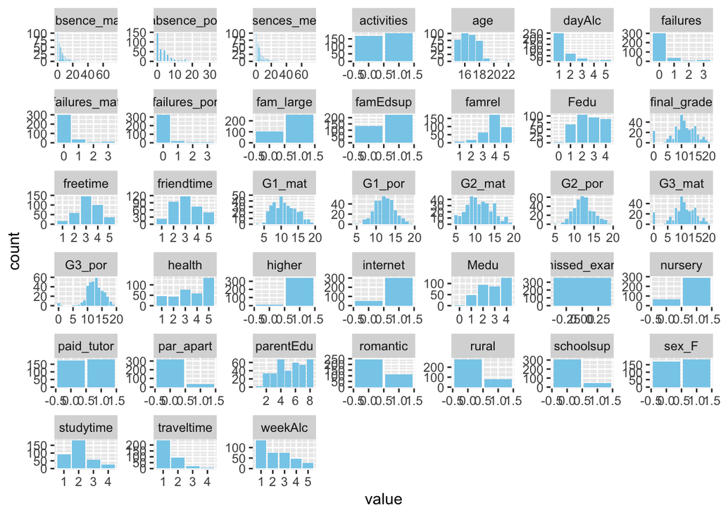